# Part I - Flights: Airline on-time performance

## Introduction

Our work here focuses on finding one or more potential factor(s) that would be related to the delay or cancellation of commercial flights. Our dataset contains millions of rows of airline (commercial) punctuality data in the United States between October 1987 and April 2008 available [here](https://dataverse.harvard.edu/dataset.xhtml?persistentId=doi:10.7910/DVN/HG7NV7) (for memory reasons, we will only work with data from the year 2007).

In this first part, I will proceed to the gathering of the dataset, then the data-wrangling and finally the exploratory analysis.

## Gathering data

We will automatically download the datasets in csv format. Then extract these files because they are all compressed and finally clean our working directory by deleting all compressed files (.bz2 format).

```python
# import all packages and set plots to be embedded inline
import requests
import bz2
import os
import json
import glob
import numpy as np
import pandas as pd
import matplotlib.pyplot as plt
import seaborn as sb

%matplotlib inline
```

#### Lest's download the metadata in order to extract the urls for the automatic download of the datasets

We got the link of the metadata in json format from this [link here](https://dataverse.harvard.edu/dataset.xhtml?persistentId=doi%3A10.7910%2FDVN%2FHG7NV7&version=&q=&fileTypeGroupFacet=&fileAccess=&fileTag=%222.+Data%22&fileSortField=&fileSortOrder=). Then we save the file in the workspace.

```python
# # Define work directiries
# folder = 'data'

# # Make directory if it doesn't already exist
# if not os.path.exists(folder):
#     os.makedirs(folder)

# # Get metadata to extract the urls
# url = 'https://dataverse.harvard.edu/api/datasets/export?exporter=dataverse_json&persistentId=doi%3A10.7910/DVN/HG7NV7'
# response = requests.get(url)

# # Save it in export.json file
# with open('./data/export.json', mode='wb') as file:
#     file.write(response.content)
```

#### Now we can extract the urls and names of the corresponding compressed files.

```python
# # Get all urls and all compressed filenames
# filenames = []
# urls = []
# start_url = 'https://dataverse.harvard.edu/api/access/datafile/:persistentId?persistentId='

# with open(os.path.join(folder,'export.json'), mode='r') as file:
#     line = file.read()
#     parsed_json = json.loads(line)

#     nb = 2008 - 1987 + 1  #Number of years of collection
#     range_val = np.arange(0, nb, 1)

#     for i in range_val:
#         filename = parsed_json.get('datasetVersion').get('files')[i].get('dataFile').get('filename')
#         end_url = parsed_json.get('datasetVersion').get('files')[i].get('dataFile').get('persistentId')

#         filenames.append(filename)
#         urls.append(start_url+end_url)
```

#### Now let's download these files from the urls retrieved before then proceed to extract the files

```python
# # Get all compressed files and extract it
# # The loop downloads for each url the corresponding file, extracts the csv file and deletes the compressed file
# for url, filename in zip(urls, filenames):

#     response = requests.get(url)

#     file_path = os.path.join(folder, filename) # path to file

#     # Extracts the csv file
#     with open(file_path , mode='wb') as zip_file:
#         zip_file.write(response.content)

#     with bz2.open(file_path, 'rb') as unzip_file:
#         file_content = unzip_file.read()
#         with open(file_path[:-4], mode='wb') as csv_file:
#             csv_file.write(file_content)

#     os.remove(file_path) # Deletes the compressed file
```

## Preliminary Wrangling

> For memory reasons, downloading data of 2007

```python
# load in the dataset into a pandas dataframe
df = pd.read_csv('./data/2007.csv')
```

```python
# # load in the dataset into a pandas dataframe
# df = pd.DataFrame()
# for file in glob.glob('./data/*.csv'):
#     df1 = pd.read_csv(file)
#     df = pd.concat([df, df1], ignore_index=True)
```

```python
# overview of data
print(df.shape)
print(df.dtypes)
print(df.isnull().sum())
df.sample(10)
```

```
(7453215, 29)
Year                   int64
Month                  int64
DayofMonth             int64
DayOfWeek              int64
DepTime              float64
CRSDepTime             int64
ArrTime              float64
CRSArrTime             int64
UniqueCarrier         object
FlightNum              int64
TailNum               object
ActualElapsedTime    float64
CRSElapsedTime       float64
AirTime              float64
ArrDelay             float64
DepDelay             float64
Origin                object
Dest                  object
Distance               int64
TaxiIn                 int64
TaxiOut                int64
Cancelled              int64
CancellationCode      object
Diverted               int64
CarrierDelay           int64
WeatherDelay           int64
NASDelay               int64
SecurityDelay          int64
LateAircraftDelay      int64
dtype: object
Year                       0
Month                      0
DayofMonth                 0
DayOfWeek                  0
DepTime               160748
CRSDepTime                 0
ArrTime               177927
CRSArrTime                 0
UniqueCarrier              0
FlightNum                  0
TailNum                   22
ActualElapsedTime     177927
CRSElapsedTime           994
AirTime               177927
ArrDelay              177927
DepDelay              160748
Origin                     0
Dest                       0
Distance                   0
TaxiIn                     0
TaxiOut                    0
Cancelled                  0
CancellationCode     7292466
Diverted                   0
CarrierDelay               0
WeatherDelay               0
NASDelay                   0
SecurityDelay              0
LateAircraftDelay          0
dtype: int64
```

|  | Year | Month | DayofMonth | DayOfWeek | DepTime | CRSDepTime | ArrTime | CRSArrTime | UniqueCarrier | FlightNum | ... | TaxiIn | TaxiOut | Cancelled | CancellationCode | Diverted | CarrierDelay | WeatherDelay | NASDelay | SecurityDelay | LateAircraftDelay |
| --- | --- | --- | --- | --- | --- | --- | --- | --- | --- | --- | --- | --- | --- | --- | --- | --- | --- | --- | --- | --- | --- |
| 3797440 | 2007 | 7 | 31 | 2 | 850.0 | 840 | 945.0 | 955 | WN | 259 | ... | 8 | 15 | 0 | NaN | 0 | 0 | 0 | 0 | 0 | 0 |
| 2795234 | 2007 | 5 | 2 | 3 | 946.0 | 951 | 1228.0 | 1235 | EV | 4846 | ... | 10 | 11 | 0 | NaN | 0 | 0 | 0 | 0 | 0 | 0 |
| 4596208 | 2007 | 8 | 26 | 7 | 1658.0 | 1701 | 1842.0 | 1859 | UA | 237 | ... | 13 | 9 | 0 | NaN | 0 | 0 | 0 | 0 | 0 | 0 |
| 3083385 | 2007 | 6 | 5 | 2 | 844.0 | 835 | 848.0 | 845 | WN | 832 | ... | 4 | 7 | 0 | NaN | 0 | 0 | 0 | 0 | 0 | 0 |
| 5122162 | 2007 | 9 | 5 | 3 | 1940.0 | 1950 | 2304.0 | 2327 | XE | 2316 | ... | 4 | 16 | 0 | NaN | 0 | 0 | 0 | 0 | 0 | 0 |
| 6742400 | 2007 | 11 | 23 | 5 | 1224.0 | 1230 | 1505.0 | 1510 | AA | 1545 | ... | 5 | 11 | 0 | NaN | 0 | 0 | 0 | 0 | 0 | 0 |
| 5276005 | 2007 | 9 | 5 | 3 | 1745.0 | 1745 | 1757.0 | 1803 | US | 1657 | ... | 5 | 13 | 0 | NaN | 0 | 0 | 0 | 0 | 0 | 0 |
| 6166090 | 2007 | 10 | 24 | 3 | 1632.0 | 1634 | 1845.0 | 1816 | AS | 390 | ... | 4 | 33 | 0 | NaN | 0 | 0 | 0 | 29 | 0 | 0 |
| 3397006 | 2007 | 6 | 25 | 1 | 1635.0 | 1635 | 1728.0 | 1735 | DL | 45 | ... | 10 | 12 | 0 | NaN | 0 | 0 | 0 | 0 | 0 | 0 |
| 4020149 | 2007 | 7 | 27 | 5 | 1625.0 | 1625 | 1712.0 | 1725 | US | 1497 | ... | 3 | 15 | 0 | NaN | 0 | 0 | 0 | 0 | 0 | 0 |

10 rows × 29 columns

```python
# print statistics
df.describe().iloc[:, 5:25]
```

|  | CRSDepTime | ArrTime | CRSArrTime | FlightNum | ActualElapsedTime | CRSElapsedTime | AirTime | ArrDelay | DepDelay | Distance | TaxiIn | TaxiOut | Cancelled | Diverted | CarrierDelay | WeatherDelay | NASDelay | SecurityDelay | LateAircraftDelay |
| --- | --- | --- | --- | --- | --- | --- | --- | --- | --- | --- | --- | --- | --- | --- | --- | --- | --- | --- | --- |
| count | 7.453215e+06 | 7.275288e+06 | 7.453215e+06 | 7.453215e+06 | 7.275288e+06 | 7.452221e+06 | 7.275288e+06 | 7.275288e+06 | 7.292467e+06 | 7.453215e+06 | 7.453215e+06 | 7.453215e+06 | 7.453215e+06 | 7.453215e+06 | 7.453215e+06 | 7.453215e+06 | 7.453215e+06 | 7.453215e+06 | 7.453215e+06 |
| mean | 1.330596e+03 | 1.482105e+03 | 1.495392e+03 | 2.188099e+03 | 1.263223e+02 | 1.272502e+02 | 1.028159e+02 | 1.019218e+01 | 1.139914e+01 | 7.198058e+02 | 6.691984e+00 | 1.630015e+01 | 2.156761e-02 | 2.304911e-03 | 3.865236e+00 | 7.700904e-01 | 3.783702e+00 | 2.373553e-02 | 5.099134e+00 |
| std | 4.647080e+02 | 5.072241e+02 | 4.815902e+02 | 1.971958e+03 | 7.118009e+01 | 7.035750e+01 | 6.824577e+01 | 3.930774e+01 | 3.614189e+01 | 5.623051e+02 | 5.151351e+00 | 1.183396e+01 | 1.452668e-01 | 4.795413e-02 | 2.084240e+01 | 9.619547e+00 | 1.617670e+01 | 1.084995e+00 | 2.127753e+01 |
| min | 0.000000e+00 | 1.000000e+00 | 0.000000e+00 | 1.000000e+00 | 1.200000e+01 | -1.240000e+03 | 0.000000e+00 | -3.120000e+02 | -3.050000e+02 | 1.100000e+01 | 0.000000e+00 | 0.000000e+00 | 0.000000e+00 | 0.000000e+00 | 0.000000e+00 | 0.000000e+00 | 0.000000e+00 | 0.000000e+00 | 0.000000e+00 |
| 25% | 9.300000e+02 | 1.107000e+03 | 1.115000e+03 | 5.900000e+02 | 7.600000e+01 | 7.700000e+01 | 5.500000e+01 | -9.000000e+00 | -4.000000e+00 | 3.190000e+02 | 4.000000e+00 | 1.000000e+01 | 0.000000e+00 | 0.000000e+00 | 0.000000e+00 | 0.000000e+00 | 0.000000e+00 | 0.000000e+00 | 0.000000e+00 |
| 50% | 1.322000e+03 | 1.513000e+03 | 1.520000e+03 | 1.509000e+03 | 1.080000e+02 | 1.100000e+02 | 8.400000e+01 | 0.000000e+00 | 0.000000e+00 | 5.690000e+02 | 5.000000e+00 | 1.400000e+01 | 0.000000e+00 | 0.000000e+00 | 0.000000e+00 | 0.000000e+00 | 0.000000e+00 | 0.000000e+00 | 0.000000e+00 |
| 75% | 1.720000e+03 | 1.911000e+03 | 1.906000e+03 | 3.553000e+03 | 1.560000e+02 | 1.560000e+02 | 1.310000e+02 | 1.400000e+01 | 1.100000e+01 | 9.460000e+02 | 8.000000e+00 | 1.900000e+01 | 0.000000e+00 | 0.000000e+00 | 0.000000e+00 | 0.000000e+00 | 0.000000e+00 | 0.000000e+00 | 0.000000e+00 |
| max | 2.359000e+03 | 2.400000e+03 | 2.400000e+03 | 9.602000e+03 | 1.270000e+03 | 1.430000e+03 | 1.257000e+03 | 2.598000e+03 | 2.601000e+03 | 4.962000e+03 | 5.450000e+02 | 5.300000e+02 | 1.000000e+00 | 1.000000e+00 | 2.580000e+03 | 1.429000e+03 | 1.386000e+03 | 3.820000e+02 | 1.031000e+03 |

1. Vérifions s'il existe des doublons dans les données et supprimons les.

```python
# print total duplicated rows
df.duplicated().sum()
```

```
27
```

```python
# drop duplicated rows
df.drop_duplicates(inplace=True)
df.reset_index(inplace=True, drop=True)

# Check working
df.duplicated().sum()
```

```
0
```

```python
# # create a full date column
# df['FullDate'] = pd.to_datetime({'year':df.Year,
#                                  'month':df.Month,
#                                  'day':df.DayofMonth})
# df[['Year', 'Month', 'DayofMonth', 'FullDate']]
```

Define categorical type on **DayofMonth, DayOfWeek, Month, Year, Cancelled, CancellationCode** and **Diverted** columns.

```python
# define the values to be replaced
df.Cancelled.replace({1:'Canceled',
                      0:'Not Canceled'}, inplace=True)
df.Diverted.replace({1:'Diverted',
                     0:'Not Diverted'}, inplace=True)
df.DayOfWeek.replace({1:'Monday',
                      2:'Tuesday',
                      3:'Wednesday',
                      4:'Thursday',
                      5:'Friday',
                      6:'Saturday',
                      7:'Sunday'}, inplace=True)
df.Month.replace({1:'January',
                  2:'February',
                  3:'March',
                  4:'April',
                  5:'May',
                  6:'June',
                  7:'July',
                  8:'August',
                  9:'September',
                  10:'October',
                  11:'November',
                  12:'December'}, inplace=True)

# convert Cancelled and Diverted category type
df['Cancelled'] = df.Cancelled.astype('category')
df['CancellationCode'] = df.CancellationCode.astype('category')
df['Diverted'] = df.Diverted.astype('category')

# convert Year, Month, DayofMonth and DayofWeek into ordered categorical types
# ordinal_var_dict = {'Year': [2003, 2004, 2005, 2006, 2007, 2008],
#                     'Month': ['January', 'February', 'March', 'April', 'May', 'June', 'July',
#                               'August', 'September', 'October', 'November', 'December'],
#                     'DayofMonth': [1, 2, 3, 4, 5, 6, 7, 8, 9, 10, 11, 12, 13, 14, 15, 16, 17,
#                                    18, 19, 20, 21, 22, 23, 24, 25, 26, 27 ,28, 29, 30, 31],
#                     'DayOfWeek': ['Monday', 'Tuesday', 'Wednesday', 'Thursday', 'Friday', 'Saturday', 'Sunday']}

ordinal_var_dict = {'Month': ['January', 'February', 'March', 'April', 'May', 'June', 'July',
                              'August', 'September', 'October', 'November', 'December'],
                    'DayofMonth': [1, 2, 3, 4, 5, 6, 7, 8, 9, 10, 11, 12, 13, 14, 15, 16, 17,
                                   18, 19, 20, 21, 22, 23, 24, 25, 26, 27 ,28, 29, 30, 31],
                    'DayOfWeek': ['Monday', 'Tuesday', 'Wednesday', 'Thursday', 'Friday', 'Saturday', 'Sunday']}

for var in ordinal_var_dict:
    ordered_var = pd.api.types.CategoricalDtype(ordered = True,
                                                categories = ordinal_var_dict[var])
    df[var] = df[var].astype(ordered_var)

# let's create two new categorical columns to signify the delays at departure
# and at arrival. Is late if ArrDelay or DepDelay is greater than 15 minutes.

late_arrival = []
late_departure =[]

for row in range(df.shape[0]):
    x = df['ArrDelay'][row]
    if x < 15:
        late_arrival.append('NO')
    else:
        late_arrival.append('YES')
for row in range(df.shape[0]):
    y = df['DepDelay'][row]
    if y < 15:
        late_departure.append('NO')
    else:
        late_departure.append('YES')

# add two columns
df['LateArr'] = late_arrival
df['LateDep'] = late_departure

# convert LateArr and LateDep into ordered categorical types
df['LateArr'] = df.LateArr.astype('category')
df['LateDep'] = df.LateDep.astype('category')

# Check working
df.dtypes
```

```
Year                    int64
Month                category
DayofMonth           category
DayOfWeek            category
DepTime               float64
CRSDepTime              int64
ArrTime               float64
CRSArrTime              int64
UniqueCarrier          object
FlightNum               int64
TailNum                object
ActualElapsedTime     float64
CRSElapsedTime        float64
AirTime               float64
ArrDelay              float64
DepDelay              float64
Origin                 object
Dest                   object
Distance                int64
TaxiIn                  int64
TaxiOut                 int64
Cancelled            category
CancellationCode     category
Diverted             category
CarrierDelay            int64
WeatherDelay            int64
NASDelay                int64
SecurityDelay           int64
LateAircraftDelay       int64
LateArr              category
LateDep              category
dtype: object
```

> Let's save the cleaned data to a file

```python
# df.to_csv('./data/clean_2007.csv', index=False)
```

### What is the structure of your dataset?

#### Definition of variables:

1. **Year** : 2007
2. **Month** : 1-12
3. **DayofMonth** : 1-31
4. **DayOfWeek** : 1 (Monday) - 7 (Sunday)
5. **DepTime** : actual departure time (local, hhmm)
6. **CRSDepTime** : scheduled departure time (local, hhmm)
7. **ArrTime** : actual arrival time (local, hhmm)
8. **CRSArrTime** : scheduled arrival time (local, hhmm)
9. **UniqueCarrier** : unique carrier code

| Code | UA | US | WN | MQ | NW | OO | XE | DL | EV | FL |
| --- | --- | --- | --- | --- | --- | --- | --- | --- | --- | --- |
| **Description** | United Air Lines Inc. | US Airways Inc. | Southwest Airlines Co. | Envoy Air | Northwest Airlines Inc. | Northwest Airlines Inc. | SkyWest Airlines Inc. | Delta Air Lines Inc. | ExpressJet Airlines LLC | AirTran Airways Corporation |

| Code | AA | AS | B6 | CO | HA | OH | F9 | YV | AQ | 9E |
| --- | --- | --- | --- | --- | --- | --- | --- | --- | --- | --- |
| **Description** | American Airlines Inc. | Alaska Airlines Inc. | JetBlue Airways | Continental Air Lines Inc. | Hawaiian Airlines Inc. | PSA Airlines Inc. | Frontier Airlines Inc. | Mesa Airlines Inc. | Aloha Airlines Inc. | Endeavor Air Inc. |

10. **FlightNum** : flight number
11. **TailNum** : plane tail number
12. **ActualElapsedTime** : Elapsed Time of Flight in minutes
13. **CRSElapsedTime** : CRS Elapsed Time of Flight in minutes (flight time estimated by the computer reservation system - CRS)
14. **AirTime** : Flight Time in minutes
15. **ArrDelay** : arrival delay, in minutes
16. **DepDelay** : departure delay, in minutes
17. **Origin** : origin IATA airport code
18. **Dest** : destination IATA airport code
19. **Distance** : distance between airports in miles
20. **TaxiIn** : the time elapsed between wheels down and arrival at the destination airport gate in minutes
21. **TaxiOut** : the time elapsed between departure from the origin airport gate and wheels off in minutes
22. **Cancelled** : cancelled Flight Indicator (1=yes, 0=no)
23. **CancellationCode** : reason for cancellation (A = carrier, B = weather, C = NAS, D = security)

| Code | A | B | C | D |
| --- | --- | --- | --- | --- |
| **Meaning** | Carrier | Weather | National Air System (NAS) | Security |

24. **Diverted** : diverted Flight Indicator (1=Yes, 0=no)
25. **CarrierDelay** : carrier Delay in minutes (data starts 6/2003)
26. **WeatherDelay** : Weather Delay in minutes (data starts 6/2003)
27. **NASDelay** : National Air System Delay in minutes (data starts 6/2003)
28. **SecurityDelay** : Security Delay in minutes (data starts 6/2003)
29. **LateAircraftDelay** : Late Aircraft Delay in minutes (data starts 6/2003)
30. **LateArr** : YES, if ArrDelay > 15 min and NO if ArrDelay < 15 min
31. **LateDep** : YES, if DepDelay > 15 min and NO if DepDelay < 15 min

### What is/are the main feature(s) of interest in your dataset?

I'm more interested in features that best predict delays or cancellations:

> - What is the best time of week/time of year to fly to minimize delays?
> - Are some carriers subject to more delays?

### What features in the dataset do you think will help support your investigation into your feature(s) of interest?

I will inspect the effects of day of week/time of year and carrier on flight punctuality.

## Univariate Exploration

```python
# load in the dataset into a pandas dataframe
# df = pd.read_csv('./data/clean_2007.csv')
```

I'll start by looking at the distribution of the mains variables of interest: DepDelay and ArrDelay.

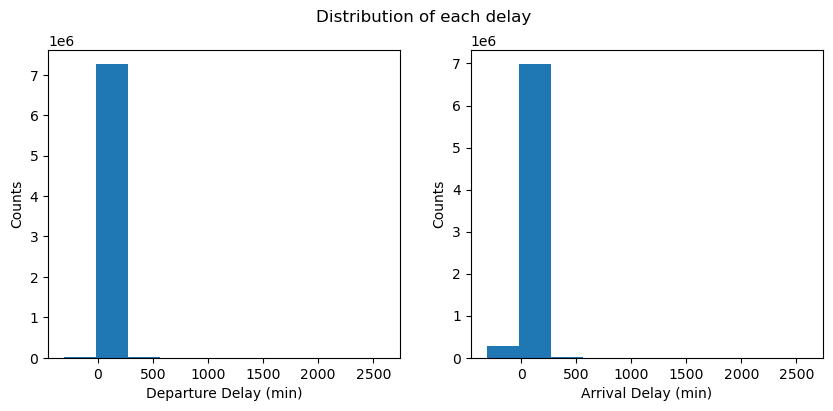

```python
# start with a standard-scaled plot
plt.figure(figsize=(10, 4))
plt.suptitle('Distribution of each delay')

plt.subplot(1, 2, 1)
plt.hist(data=df, x='DepDelay')
# plt.title('Distribution of punctuality at arrival')
plt.xlabel('Departure Delay (min)')
plt.ylabel('Counts')

plt.subplot(1, 2, 2)
plt.hist(data=df, x='ArrDelay')
# plt.title('Distribution of punctuality at arrival')
plt.xlabel('Arrival Delay (min)')
plt.ylabel('Counts');
```

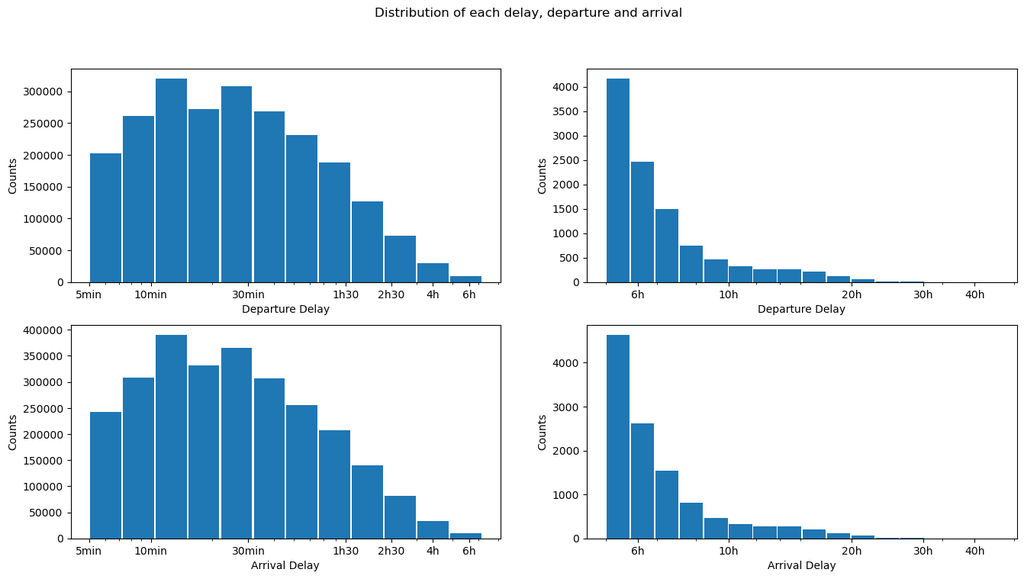

```python
# plot on a logarithmic-scale, there is a concentration around 0 in the distribution, so let's set the limits split it

plt.figure(figsize=(16, 8))


plt.suptitle('Distribution of each delay, departure and arrival')

plt.subplot(2, 2, 1)
bins_edge_arr = 10**np.arange(np.log10(5), np.log10(360)+0.16, 0.16)
plt.hist(data=df, x='DepDelay', bins=bins_edge_arr, rwidth=0.95)
plt.xscale('log')
plt.xticks([5, 10, 30, 90, 150, 240, 360,], ['5min', '10min', '30min', '1h30', '2h30', '4h', '6h'])
plt.xlabel('Departure Delay')
plt.ylabel('Counts')

plt.subplot(2, 2, 2)
bins_edge_arr = 10**np.arange(np.log10(300), np.log10(df['DepDelay'].max())+0.06, 0.06)
plt.hist(data=df, x='DepDelay', bins=bins_edge_arr, rwidth=0.95)
plt.xscale('log')
plt.xticks([360, 600, 1200, 1800, 2400], ['6h','10h', '20h', '30h', '40h'])
plt.xlabel('Departure Delay')
plt.ylabel('Counts')

plt.subplot(2, 2, 3)
bins_edge_dep = 10**np.arange(np.log10(5), np.log10(360)+0.16, 0.16)
plt.hist(data=df, x='ArrDelay', bins=bins_edge_dep, rwidth=0.95)
plt.xscale('log')
plt.xticks([5, 10, 30, 90, 150, 240, 360], ['5min', '10min', '30min', '1h30', '2h30', '4h', '6h'])
plt.xlabel('Arrival Delay')
plt.ylabel('Counts')


plt.subplot(2, 2, 4)
bins_edge_dep = 10**np.arange(np.log10(300), np.log10(df.ArrDelay.max())+0.06, 0.06)
plt.hist(data=df, x='ArrDelay', bins=bins_edge_dep, rwidth=0.95)
plt.xscale('log')
plt.xticks([360, 600, 1200, 1800, 2400], ['6h','10h', '20h', '30h', '40h'])
plt.xlabel('Arrival Delay')
plt.ylabel('Counts');
```

How are the DAyOfWeek, Month, DayofMonth, UniqueCarrier variables distributed?

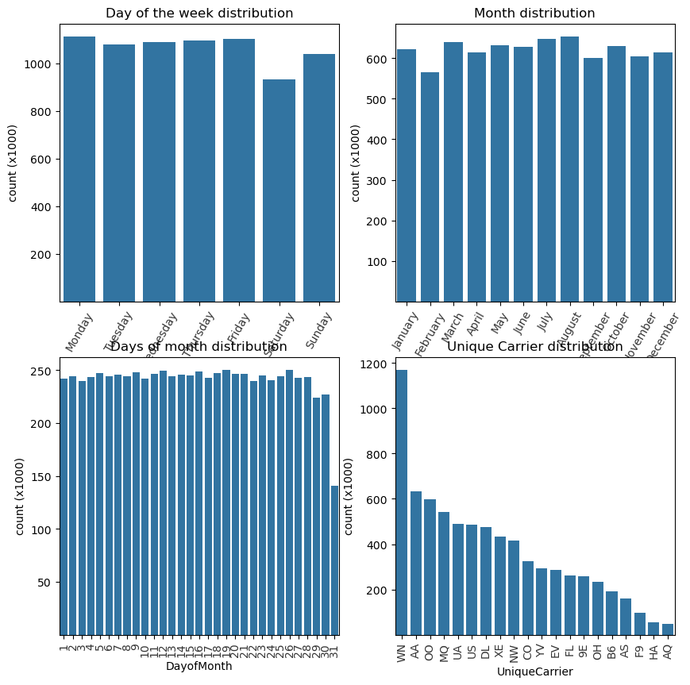

```python
# plot on a logarithmic-scale the distribution of DayOfWeek, Month, DayofMonth, UniqueCarrier
plt.figure(figsize=(10, 10))
base_color = sb.color_palette()[0]
orders = df.UniqueCarrier.value_counts().index

plt.subplot(2, 2, 1)
sb.countplot(data=df, x='DayOfWeek', color=base_color)
plt.title('Day of the week distribution')
plt.xticks(rotation=60, alpha=0.8)
plt.yticks([2e5, 4e5, 6e5, 8e5, 1e6], ['200', '400', '600', '800', '1000'])
plt.ylabel('count (x1000)');

plt.subplot(2, 2, 2)
sb.countplot(data=df, x='Month', color=base_color)
plt.title('Month distribution')
plt.xticks(rotation=60, alpha=0.8)
plt.yticks([1e5, 2e5, 3e5, 4e5, 5e5, 6e5], ['100', '200', '300', '400', '500', '600'])
plt.ylabel('count (x1000)');

plt.subplot(2, 2, 3)
sb.countplot(data=df, x='DayofMonth', color=base_color)
plt.title('Days of month distribution')
plt.xticks(rotation=90, alpha=0.8)
plt.yticks([5e4, 1e5, 1.5e5, 2e5, 2.5e5], ['50', '100', '150', '200', '250'])
plt.ylabel('count (x1000)');

plt.subplot(2, 2, 4)
base_color = sb.color_palette()[0]
sb.countplot(data=df, x='UniqueCarrier', color=base_color, order=orders)
plt.title('Unique Carrier distribution')
plt.xticks(rotation=90, alpha=0.8)
plt.yticks([2e5, 4e5, 6e5, 8e5, 1e6, 1.2e6], ['200', '400', '600', '800', '1000', '1200'])
plt.ylabel('count (x1000)');
```

We can notice that the flights are quite constant between Monday and Friday with a slight decrease on weekends. We also notice that Southwest Airlines Co. (WN) has more flights than the rest, followed by American Airlines Inc. (AA). Aloha Airlines Inc. (AQ) and Hawaiian Airlines Inc (AH) each total less than 100 miles flights, it is possible that these are new companies trying to find a place in a market dominated by companies like Southwest Airlines. We also notice that there are more flights in the summer period, mainly in July and August.

Now, how are the Cancelled, CancellationCode, Diverted, LateArr and LateDep variables distributed?

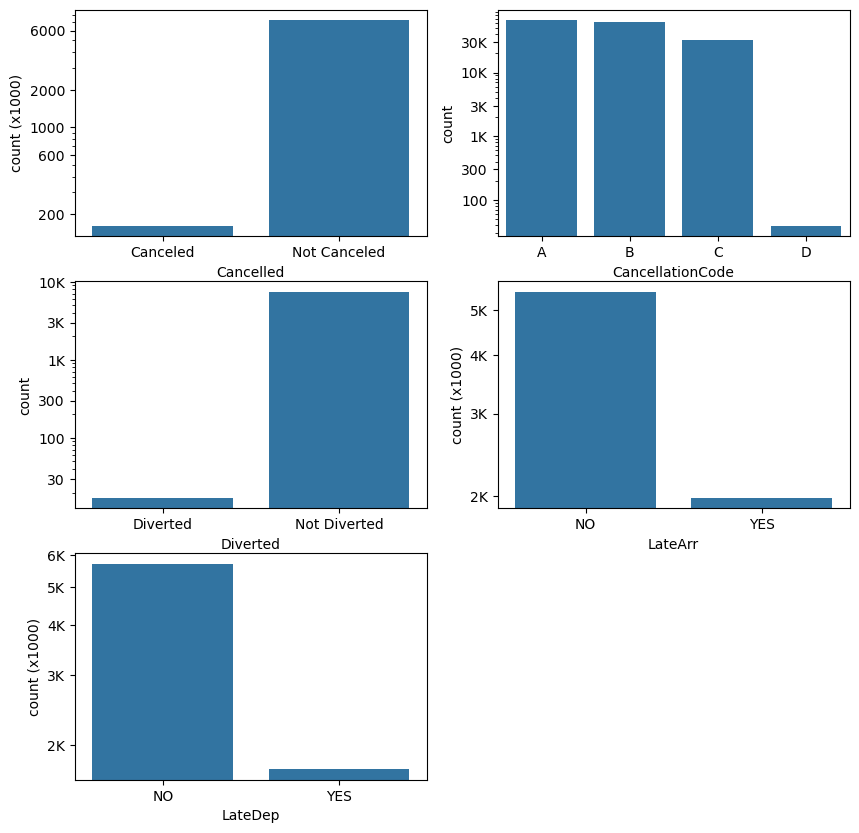

```python
# plot on a logarithmic-scale the distribution of the Cancelled, CancellationCode, Diverted, LateArr and LateDep variables
plt.figure(figsize=(10, 10))
base_color = sb.color_palette()[0]

plt.subplot(3, 2, 1)
sb.countplot(data=df, x='Cancelled', color=base_color)
plt.yscale('log')
plt.yticks([2e5, 6e5, 1e6, 2e6, 6e6], ['200', '600', '1000', '2000', '6000'])
plt.ylabel('count (x1000)');

plt.subplot(3, 2, 2)
sb.countplot(data=df, x='CancellationCode', color=base_color)
plt.yscale('log')
plt.yticks([1e2, 3e2, 1e3, 3e3, 1e4, 3e4], ['100', '300', '1K', '3K', '10K', '30K']);

plt.subplot(3, 2, 3)
sb.countplot(data=df, x='Diverted', color=base_color)
plt.yscale('log')
plt.yticks([3e4, 1e5, 3e5, 1e6, 3e6, 1e7], ['30', '100', '300', '1K', '3K', '10K'])
plt.ylabel('count');

plt.subplot(3, 2, 4)
sb.countplot(data=df, x='LateArr', color=base_color)
plt.yscale('log')
plt.yticks([2e6, 3e6, 4e6, 5e6], ['2K', '3K', '4K', '5K'])
plt.ylabel('count (x1000)');

plt.subplot(3, 2, 5)
sb.countplot(data=df, x='LateDep', color=base_color)
plt.yscale('log')
plt.yticks([2e6, 3e6, 4e6, 5e6, 6e6], ['2K', '3K', '4K', '5K', '6K'])
plt.ylabel('count (x1000)');
```

### Discuss the distribution(s) of your variable(s) of interest. Were there any unusual points? Did you need to perform any transformations?

The values of the LateDep, LateArr, Diverted, CancellationCode and Canceled variables take a large number range, so we applied a logarithmic transformation.

### Of the features you investigated, were there any unusual distributions? Did you perform any operations on the data to tidy, adjust, or change the form of the data? If so, why did you do this?

We've made a quality improvement by removing duplicate entries and adding columns that summarize others.

## Bivariate Exploration

data. Make sure the variables that you cover here have been introduced in some fashion in the previous section (univariate exploration).

Is there a relationship between departure delay and arrival delay?

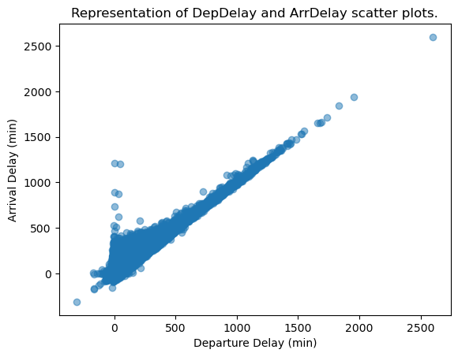

```python
# relation between departure delay and arrival delay
plt.scatter(data=df, x='DepDelay', y='ArrDelay', alpha=0.5)
plt.title('Representation of DepDelay and ArrDelay scatter plots.')
plt.xlabel('Departure Delay (min)')
plt.ylabel('Arrival Delay (min)');
```

The hypothesis mentioned above according to which the delay before departure automatically leads to a delay on arrival corroborating with this diagram, we observe an increase in the delay on arrival when the delay on departure increases. Nevertheless, a good number of on-time pati flights arrive late.

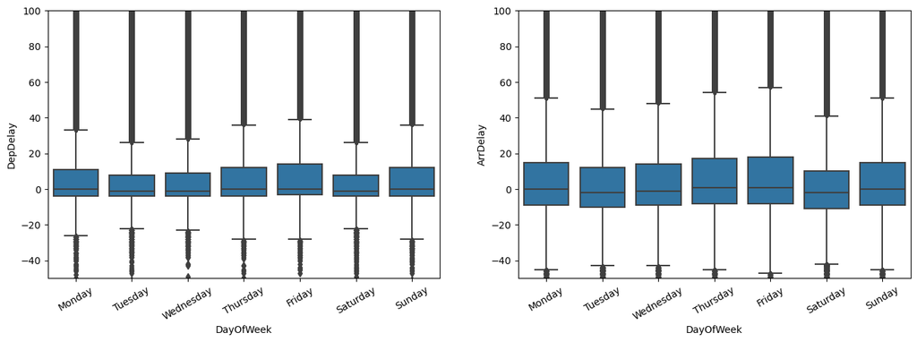

```python
# statistics between the day of the week, delay of departure and delay of arrival
plt.figure(figsize=(16, 5))

plt.subplot(1, 2, 1)
sb.boxplot(data=df, x='DayOfWeek', y='DepDelay', color=base_color)
plt.ylim(-50, 100)
plt.xticks(rotation=30)

plt.subplot(1, 2, 2)
sb.boxplot(data=df, x='DayOfWeek', y='ArrDelay', color=base_color)
plt.ylim(-50, 100)
plt.xticks(rotation=30);
```

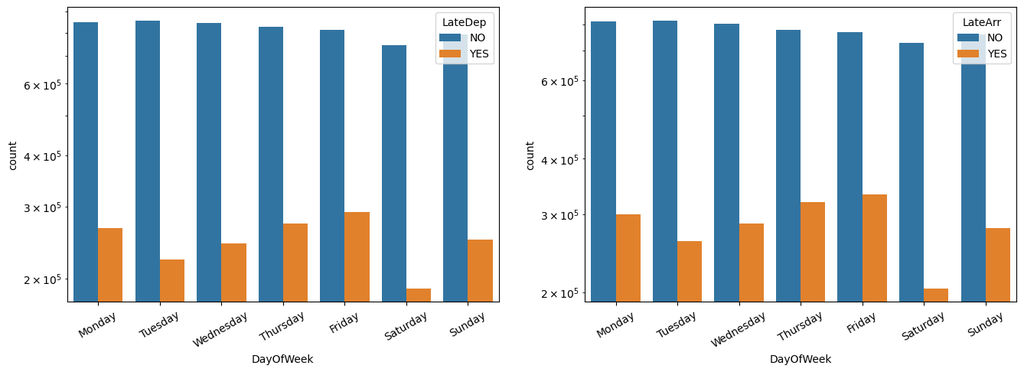

```python
# plots on a logarithmic-scale of shares of late at departure, late at arrival in relation to day of the week
plt.figure(figsize=(16, 5))

plt.subplot(1, 2, 1)
sb.countplot(data=df, x='DayOfWeek', hue='LateDep')
plt.yscale('log')
plt.xticks(rotation=30)

plt.subplot(1, 2, 2)
sb.countplot(data=df, x='DayOfWeek', hue='LateArr')
plt.yscale('log')
plt.xticks(rotation=30);
```

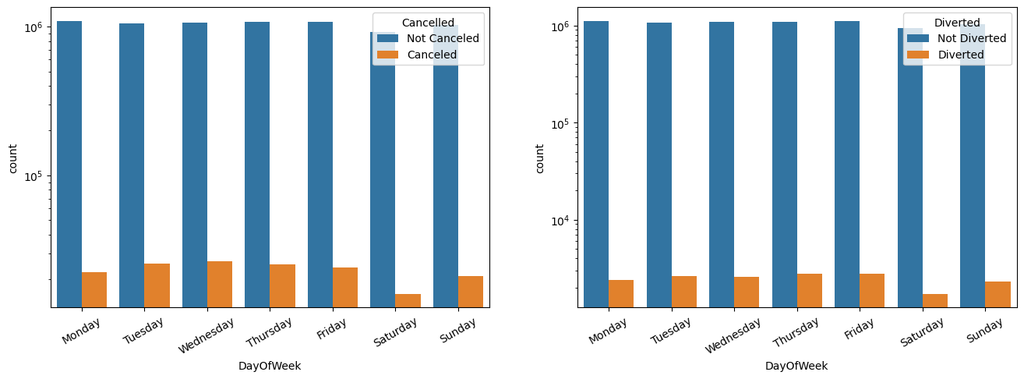

```python
# Plots on a logarithmic-scale of shares of cancellation, diversion in relation to day of the week
plt.figure(figsize=(16, 5))

plt.subplot(1, 2, 1)
sb.countplot(data=df, x='DayOfWeek', hue='Cancelled', hue_order=['Not Canceled', 'Canceled'])
plt.yscale('log')
plt.xticks(rotation=30)

plt.subplot(1, 2, 2)
sb.countplot(data=df, x='DayOfWeek', hue='Diverted', hue_order=['Not Diverted', 'Diverted'])
plt.yscale('log')
plt.xticks(rotation=30);
```

```python
def rate_evaluate1(var1, var2, var3):
    value = df.groupby([var1, var2])[var3].count().values
    plage = np.arange(0, len(value)+2, 2 )
    length = len(value)
    ratio = {}

    for i in plage:
        if i == length:
            break
        else:
            label = df.groupby([var1, var2])[var3].count().index[i][0]
            ratio[label] = 100*value[i+1]/(value[i+1] + value[i])

#     pct = pd.Series(data=ratio)
    return pd.Series(data=ratio)

def rate_evaluate2(var1, var2, var3):
    value = df.groupby([var1, var2])[var3].count().values
    plage = np.arange(0, len(value)+2, 2 )
    length = len(value)
    ratio = {}

    for i in plage:
        if i == length:
            break
        else:
            label = df.groupby([var1, var2])[var3].count().index[i][0]
            ratio[label] = 100*value[i]/(value[i+1] + value[i])

#     pct = pd.Series(data=ratio)
    return pd.Series(data=ratio)
```

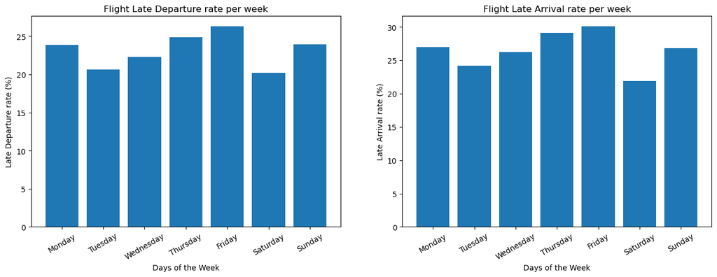

```python
# ratio between day of the week - lateness rate at departure and day of the week - lateness rate at arrival
plt.figure(figsize=(16, 5))

plt.subplot(1, 2, 1)

df_sub = rate_evaluate1('DayOfWeek', 'LateDep', 'Year')
plt.bar(df_sub.index, df_sub.values);
plt.title('Flight Late Departure rate per week')
plt.ylabel('Late Departure rate (%)')
plt.xlabel('Days of the Week')
plt.xticks(rotation=30);

plt.subplot(1, 2, 2)
df_sub = rate_evaluate1('DayOfWeek', 'LateArr', 'Year')
plt.bar(df_sub.index, df_sub.values);
plt.title('Flight Late Arrival rate per week')
plt.ylabel('Late Arrival rate (%)')
plt.xlabel('Days of the Week')
plt.xticks(rotation=30);
```

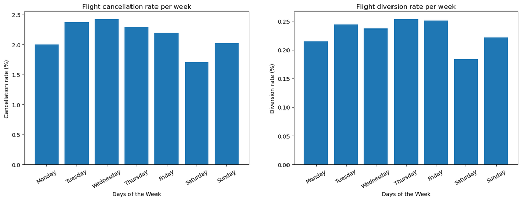

```python
# ratio between day of the week - cancellation rate and day of the week - diversion rate
plt.figure(figsize=(16, 5))

plt.subplot(1, 2, 1)

df_sub = rate_evaluate2('DayOfWeek', 'Cancelled', 'Year')
plt.bar(df_sub.index, df_sub.values);
plt.title('Flight cancellation rate per week')
plt.ylabel('Cancellation rate (%)')
plt.xlabel('Days of the Week')
plt.xticks(rotation=30);

plt.subplot(1, 2, 2)
df_sub = rate_evaluate2('DayOfWeek', 'Diverted', 'Year')
plt.bar(df_sub.index, df_sub.values)
plt.title('Flight diversion rate per week')
plt.ylabel('Diversion rate (%)')
plt.xlabel('Days of the Week')
plt.xticks(rotation=30);
```

We can observe in these two charts that the medians for each day of the week are close to zero, but have a lot of outliers. In conclusion here we remember that the best day of the week to travel in order to minimize the delay or the cancellation of flight or a diversion is Saturday.

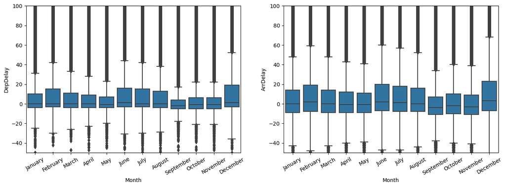

```python
# statistics between the month delay of departure and delay of arrival
plt.figure(figsize=(16, 5))

plt.subplot(1, 2, 1)
sb.boxplot(data=df, x='Month', y='DepDelay', color=base_color)
plt.ylim(-50, 100)
plt.xticks(rotation=30)

plt.subplot(1, 2, 2)
sb.boxplot(data=df, x='Month', y='ArrDelay', color=base_color)
plt.ylim(-50, 100)
plt.xticks(rotation=30);
```

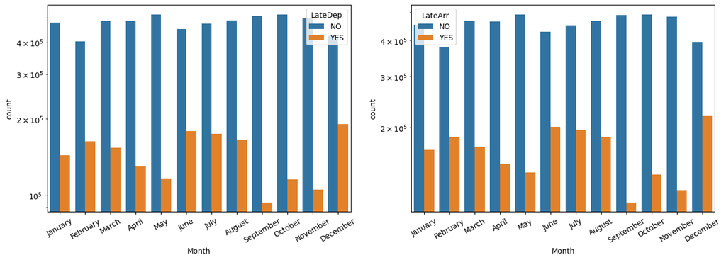

```python
# Plots on a logarithmic-scale of shares of late departure, late arrival in relation to carriers
plt.figure(figsize=(16, 5))

plt.subplot(1, 2, 1)
sb.countplot(data=df, x='Month', hue='LateDep')
plt.yscale('log')
plt.xticks(rotation=30)

plt.subplot(1, 2, 2)
sb.countplot(data=df, x='Month', hue='LateArr')
plt.yscale('log')
plt.xticks(rotation=30);
```

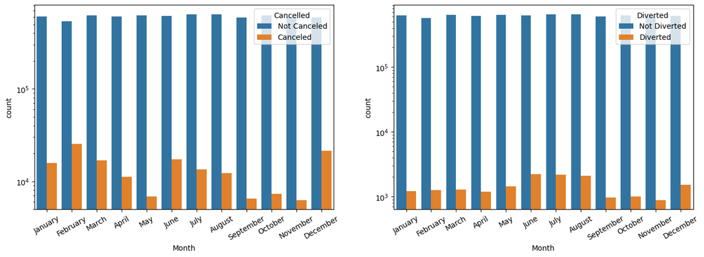

```python
# Plots on a logarithmic-scale of shares of cancellation, diversion in relation to carriers
plt.figure(figsize=(16, 5))

plt.subplot(1, 2, 1)
sb.countplot(data=df, x='Month', hue='Cancelled', hue_order=['Not Canceled', 'Canceled'])
plt.yscale('log')
plt.xticks(rotation=30)

plt.subplot(1, 2, 2)
sb.countplot(data=df, x='Month', hue='Diverted', hue_order=['Not Diverted', 'Diverted'])
plt.yscale('log')
plt.xticks(rotation=30);
```

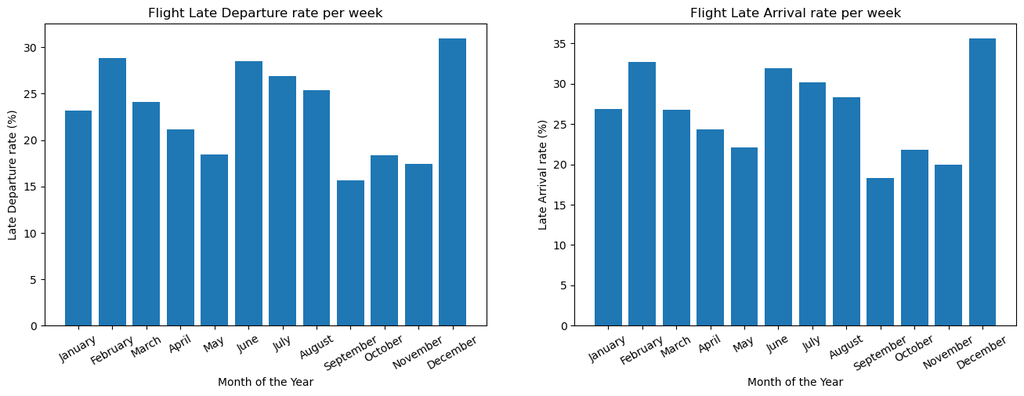

```python
# ratio between month - lateness rate at departure and month - lateness rate at arrival
plt.figure(figsize=(16, 5))

plt.subplot(1, 2, 1)
df_sub = rate_evaluate1('Month', 'LateDep', 'Year')
plt.bar(df_sub.index, df_sub.values);
plt.title('Flight Late Departure rate per week')
plt.ylabel('Late Departure rate (%)')
plt.xlabel('Month of the Year')
plt.xticks(rotation=30);

plt.subplot(1, 2, 2)
df_sub = rate_evaluate1('Month', 'LateArr', 'Year')
plt.bar(df_sub.index, df_sub.values);
plt.title('Flight Late Arrival rate per week')
plt.ylabel('Late Arrival rate (%)')
plt.xlabel('Month of the Year')
plt.xticks(rotation=30);
```

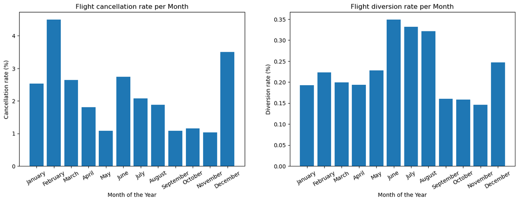

```python
# relationship between month - cancellation rate and month - diversion rate
plt.figure(figsize=(16, 5))

plt.subplot(1, 2, 1)
df_sub = rate_evaluate2('Month', 'Cancelled', 'Year')
plt.bar(df_sub.index, df_sub.values);
plt.title('Flight cancellation rate per Month')
plt.ylabel('Cancellation rate (%)')
plt.xlabel('Month of the Year')
plt.xticks(rotation=30);

plt.subplot(1, 2, 2)
df_sub = rate_evaluate2('Month', 'Diverted', 'Year')
plt.bar(df_sub.index, df_sub.values);
plt.title('Flight diversion rate per Month')
plt.ylabel('Diversion rate (%)')
plt.xlabel('Month of the Year')
plt.xticks(rotation=30);
```

We can observe in the diagram on the left that the medians for each month of the year are close to zero except for the months of June and December. As for the diagram on the right, the medians are also close to zero. However, there are a lot of outliers. In conclusion here we retain that the best months of the year to travel in order to minimize the delay or the cancellation of flight or a diversion are the months of May, September and November.

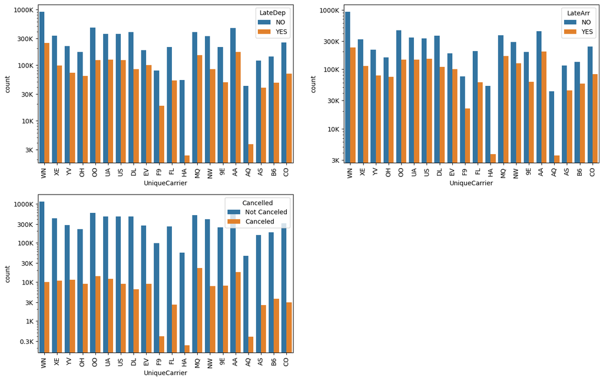

```python
# Plots on a logarithmic-scale of shares of late departure, late arrival and cancellation in relation to carriers
plt.figure(figsize=(16, 10))

plt.subplot(2, 2, 1)
sb.countplot(data=df, x='UniqueCarrier', hue='LateDep')
plt.yscale('log')
plt.yticks([3e3, 1e4, 3e4, 1e5, 3e5, 1e6], ['3K', '10K', '30K', '100K', '300K', '1000K'])
plt.xticks(rotation=90)

plt.subplot(2, 2, 2)
sb.countplot(data=df, x='UniqueCarrier', hue='LateArr')
plt.yscale('log')
plt.yticks([3e3, 1e4, 3e4, 1e5, 3e5, 1e6], ['3K', '10K', '30K', '100K', '300K', '1000K'])
plt.xticks(rotation=90);

plt.subplot(2, 2, 3)
sb.countplot(data=df, x='UniqueCarrier', hue='Cancelled', hue_order=['Not Canceled', 'Canceled'])
plt.yscale('log')
plt.yticks([3e2, 1e3, 3e3, 1e4, 3e4, 1e5, 3e5, 1e6], ['0.3K', '1K', '3K', '10K', '30K', '100K', '300K', '1000K'])
plt.xticks(rotation=90);
```

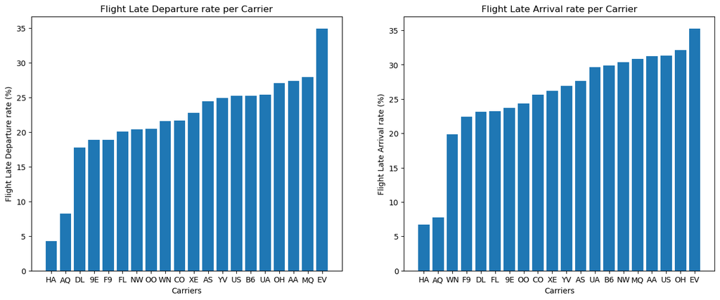

```python
# Plots of flight late departure and late arrival rates against carriers
plt.figure(figsize=(16, 6))

plt.subplot(1, 2, 1)
df_sub = rate_evaluate1('UniqueCarrier', 'LateDep', 'Year')
df_sub = df_sub.sort_values()
plt.bar(df_sub.index, df_sub.values);
plt.title('Flight Late Departure rate per Carrier')
plt.ylabel('Flight Late Departure rate (%)')
plt.xlabel('Carriers');

plt.subplot(1, 2, 2)
df_sub = rate_evaluate1('UniqueCarrier', 'LateArr', 'Year')
df_sub = df_sub.sort_values()
plt.bar(df_sub.index, df_sub.values);
plt.title('Flight Late Arrival rate per Carrier')
plt.ylabel('Flight Late Arrival rate (%)')
plt.xlabel('Carriers');
```

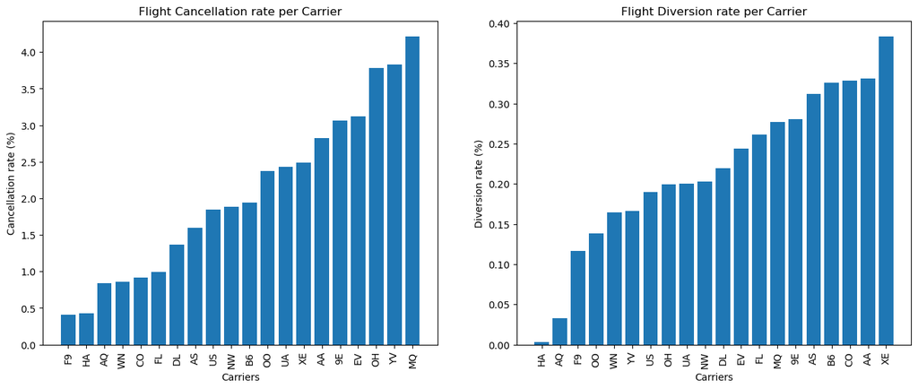

```python
# Plots of flight cancellation and diversion rates against carriers
plt.figure(figsize=(16, 6))

plt.subplot(1, 2, 1)
df_sub = rate_evaluate2('UniqueCarrier', 'Cancelled', 'Year')
df_sub = df_sub.sort_values()
plt.bar(df_sub.index, df_sub.values);
plt.title('Flight Cancellation rate per Carrier')
plt.ylabel('Cancellation rate (%)')
plt.xlabel('Carriers')
plt.xticks(rotation=90);

plt.subplot(1, 2, 2)
df_sub = rate_evaluate2('UniqueCarrier', 'Diverted', 'Year')
df_sub = df_sub.sort_values()
plt.bar(df_sub.index, df_sub.values);
plt.title('Flight Diversion rate per Carrier')
plt.ylabel('Diversion rate (%)')
plt.xlabel('Carriers')
plt.xticks(rotation=90);
```

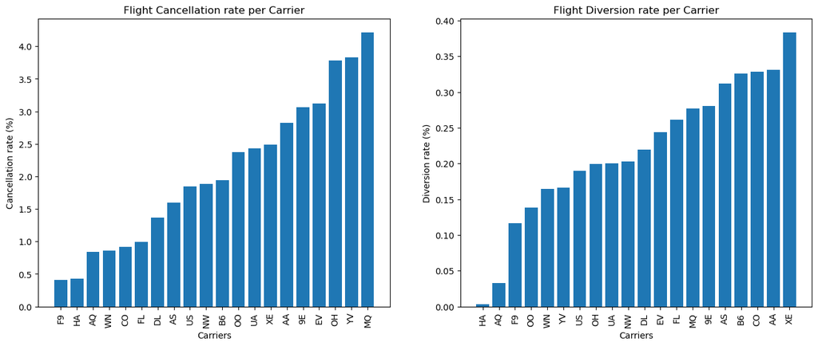

```python
# Plots of flight cancellation and diversion rates against carriers
plt.figure(figsize=(16, 6))

plt.subplot(1, 2, 1)
df_sub = rate_evaluate2('UniqueCarrier', 'Cancelled', 'Year')
df_sub = df_sub.sort_values()
plt.bar(df_sub.index, df_sub.values);
plt.title('Flight Cancellation rate per Carrier')
plt.ylabel('Cancellation rate (%)')
plt.xlabel('Carriers')
plt.xticks(rotation=90);

plt.subplot(1, 2, 2)
df_sub = rate_evaluate2('UniqueCarrier', 'Diverted', 'Year')
df_sub = df_sub.sort_values()
plt.bar(df_sub.index, df_sub.values);
plt.title('Flight Diversion rate per Carrier')
plt.ylabel('Diversion rate (%)')
plt.xlabel('Carriers')
plt.xticks(rotation=90);
```

### Did you observe any interesting relationships between the other features (not the main feature(s) of interest)?

There is a trend very increasing rate of the viarble Diverted compared to the carrier, would it be related to a possibly with the states of the planes? We could not answer this question in this study because that is not the goal here.

## Multivariate Exploration

further. Make sure that your investigations are justified, and follow from your work in the previous sections.

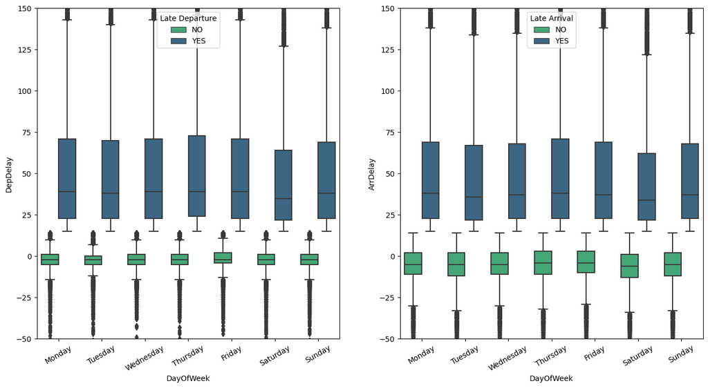

```python
# plot relationships between DayOfWeek, DepDelay, ArrDelay, LateDep and LateArr
plt.figure(figsize=(16, 8))

plt.subplot(1, 2, 1)
sb.boxplot(data=df, x='DayOfWeek', y='DepDelay', hue='LateDep', palette='viridis_r')
plt.ylim(-50, 150)
plt.xticks(rotation=30)
plt.legend(title='Late Departure', loc=9);

plt.subplot(1, 2, 2)
sb.boxplot(data=df, x='DayOfWeek', y='ArrDelay', hue='LateArr', palette='viridis_r')
plt.ylim(-50, 150)
plt.xticks(rotation=30)
plt.legend(title='Late Arrival' ,loc=9);
```

On peut voir sur ces diagrammes que les journées de mardi et samedi présente d'après ce diagramme les quatiles et les médianes de ces mois sont basses que la moyenne.

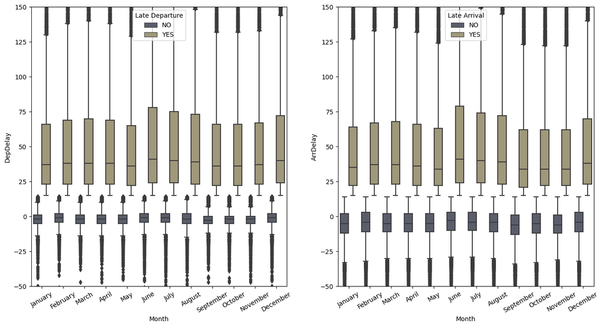

```python
# plot relationships between Month, DepDelay, ArrDelay, LateDep and LateArr
plt.figure(figsize=(16, 8))

plt.subplot(1, 2, 1)
sb.boxplot(data=df, x='Month', y='DepDelay', hue='LateDep', palette='cividis')
plt.ylim(-50, 150)
plt.xticks(rotation=30)
plt.legend(title='Late Departure', loc=9);

plt.subplot(1, 2, 2)
sb.boxplot(data=df, x='Month', y='ArrDelay', hue='LateArr', palette='cividis')
plt.ylim(-50, 150)
plt.xticks(rotation=30)
plt.legend(title='Late Arrival' ,loc=9);
```

L'observation ici reste que les mois de mai, septembre, octobre et novembre d'après ce diagramme car les quatiles et les médianes de ces mois sont basses que la moyenne.

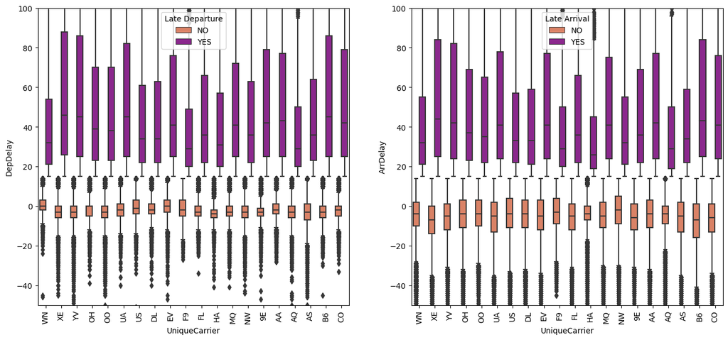

```python
# plot relationships between UniqueCarrier, DepDelay, ArrDelay, LateDep and LateArr
plt.figure(figsize=(16, 7))

plt.subplot(1, 2, 1)
sb.boxplot(data=df, x='UniqueCarrier', y='DepDelay', hue='LateDep', palette='plasma_r')
plt.ylim(-50, 100)
plt.xticks(rotation=90)
plt.legend(title='Late Departure', loc=9);

plt.subplot(1, 2, 2)
sb.boxplot(data=df, x='UniqueCarrier', y='ArrDelay', hue='LateArr', palette='plasma_r')
plt.ylim(-50, 100)
plt.xticks(rotation=90)
plt.legend(title='Late Arrival' ,loc=9);
```

### Talk about some of the relationships you observed in this part of the investigation. Were there features that strengthened each other in terms of looking at your feature(s) of interest?

Not really we get the same observations obtained with the bivariate diagrams.

### Were there any interesting or surprising interactions between features?

Not really we get the same observations obtained with the bivariate diagrams.

## Conclusions

To begin this work we started by downloading all the files necessary for the study, then proceeded to the processing then followed by the exploration which guided our study which consisted of looking for the functionalities of our data which would influence the delay or cancellation of flights: